# Homework 1 (Deadline: 11/02/2024)

Alin Ierima

## Setup

You are free to use any function/package you want (from base R or any package) to complete this assignment. Additionally, people working in Python are free to submit their work in a juptyer notebook.

For people doing it in R, please write your code in the appropriate code chunks below. You can submit a *knitted* file (html or pdf), or an `.Rmd` file. For more information on how to knit a file, please refer to the [R Markdown documentation](https://rmarkdown.rstudio.com/lesson-1.html).

```r
require(tidyverse)
library(tidytext)

# Load the data
federalist <- read_csv("data/federalist.csv")
```

## Task 1 Repeat the Authorship Analysis for All Disputed Federalist Papers

1. Identify Disputed Papers

   Look at the `author` column to find rows labeled “HAMILTON OR MADISON”
2. Author Frequencies

   Pick a set of words (e.g., the three words that we used: “man,” “by,” “upon”) + 5 other words that you think are good predictors of authorship.

   For each author (Hamilton, Madison, and Jay), compute their **word probabilities** (the ralitive rates) $\hat{\mu}_h, \hat{\mu}_m, \hat{\mu}_j$ (with Laplace+1 smoothing).
3. For Each Disputed Document

   Compute the multinomial likelihood of that document under each author’s distribution, for example, using `dmultinom(...)` function.

   Which author has the largest likelihood?
4. Either plot the results or create a table that shows the likelihood of each author for each disputed document.

```r
library(tm)
library(tidyverse)
library(ggthemes)
library(ggrepel)

# 0. Preprocessing - I adapted this from your code
preprocess <- function(text) {
  text |>
    mutate(
    text   = str_to_lower(text),                # turn all letters to lowercase
    text   = str_replace_all(text, "\n", " "),  # replace '/n' carriage return symbols
    text   = str_remove_all(text, "[:punct:]"), # remove all punctuation
    man    = str_count(text, "\\Wman "),        # Basic regex (more about it later in the course. '\\W' part means at the begging of the word) and count those up
    by     = str_count(text, "\\Wby "),         # same
    upon   = str_count(text, "\\Wupon "),
    through   = str_count(text, "\\Wthrough "),
    cannot   = str_count(text, "\\Wcannot "),
    people   = str_count(text, "\\Wpeople "),
    president   = str_count(text, "\\Wpresident "),
    state   = str_count(text, "\\Wstate ")) |>
    rowwise() |>
    mutate(
      length = length(str_split(text, "")[[1]])
    )
}

federalist_clean = tibble(federalist)
federalist_clean <- preprocess(federalist_clean)

# 1.2. Identify disputed papers, author frequencies, word frequencies
federalist_disputed_docs <- federalist_clean[federalist$author == "HAMILTON OR MADISON",] |>
  select(man,by,upon, through, cannot, people, president, state) |>
  mutate(across(everything(), as.numeric))
federalist_disputed_docs_df <- as.data.frame(federalist_disputed_docs)

federalist_hamilton <-federalist_clean[federalist$author =="HAMILTON",] |>
  select(man,by,upon, through, cannot, people, president, state) |>
  colSums()
federalist_madison <- federalist_clean[federalist$author =="MADISON",] |>
  select(man,by,upon, through, cannot, people, president, state) |>
  colSums()
federalist_jay <- federalist_clean[federalist$author =="JAY",] |>
  select(man,by,upon, through, cannot, people, president, state) |>
  colSums()

federalist_disputed_prob <- (federalist_disputed_docs +1) / (sum(federalist_disputed_docs) +1)
federalist_hamilton_prob <- (federalist_hamilton +1) / (sum(federalist_hamilton) +1)
federalist_madison_prob <- (federalist_madison +1) / (sum(federalist_madison) +1)
federalist_jay_prob <- (federalist_jay +1) / (sum(federalist_jay) +1)


# 3. Multinomial likelihood for disputed docs

calculate_likelihoods <- function(document, hamilton_prob, madison_prob, jay_prob) {
  hamilton_likelihood = dmultinom(document, prob = hamilton_prob)
  madison_likelihood = dmultinom(document, prob = madison_prob)
  jay_likelihood = dmultinom(document, prob = jay_prob)
    return(c(Hamilton = hamilton_likelihood, Madison = madison_likelihood, Jay = jay_likelihood))
}


likelihoods_list <- apply(federalist_disputed_docs_df, 1, function(document) {
  calculate_likelihoods(document, federalist_hamilton_prob, federalist_madison_prob, federalist_jay_prob)})

likelihoods_table <- as_tibble(t(likelihoods_list))
likelihoods_table <- likelihoods_table |>
  mutate(
    Doc = row_number(),
    Likely_Author = ifelse(Hamilton == pmax(Hamilton, Madison, Jay), "Hamilton",
                           ifelse(Madison == pmax(Hamilton, Madison, Jay), "Madison", "Jay"))
  )

knitr::kable(likelihoods_table)
```

| Hamilton | Madison | Jay | Doc | Likely_Author |
| --- | --- | --- | --- | --- |
| 0.00e+00 | 0.0000000 | 7.00e-07 | 1 | Jay |
| 2.08e-05 | 0.0002405 | 1.29e-05 | 2 | Madison |
| 0.00e+00 | 0.0000538 | 8.00e-07 | 3 | Madison |
| 0.00e+00 | 0.0000250 | 4.92e-05 | 4 | Jay |
| 0.00e+00 | 0.0001743 | 1.00e-07 | 5 | Madison |
| 1.00e-07 | 0.0000020 | 0.00e+00 | 6 | Madison |
| 0.00e+00 | 0.0000004 | 1.70e-06 | 7 | Jay |
| 0.00e+00 | 0.0000000 | 0.00e+00 | 8 | Madison |
| 0.00e+00 | 0.0000026 | 1.80e-06 | 9 | Madison |
| 0.00e+00 | 0.0003212 | 6.70e-06 | 10 | Madison |
| 0.00e+00 | 0.0000000 | 0.00e+00 | 11 | Jay |

## Task 2 Logged Odds Differences for Bigrams

1. Tokenize text into bigrams.
2. Either remove every bigram that contains a stopword, or remove stopwords before tokenizing into bigrams.
3. Remove the bigrams that occur only once.
4. Separate the bigrams by author (focus only Hamilton and Madison).
5. Compute the relative frequencies of bigrams for each author.
6. Compute the log odds for each bigram.

   $$\log O_b^i = \log(\frac{f_b^i}{1 - f_b^i})$$

   where $f_b^i$ is the relative frequency of bigram $b$ in author $i$.
7. Compute the log odds differences for each bigram.

   $$\Delta_{bigram} = \log(\frac{f_b^i}{1 - f_b^i}) - \log(\frac{f_b^j}{1 -
   f_b^j})$$

   where $i$ and $j$ are the authors being compared.
8. Plot the log odds differences of top discriminative bigrams.

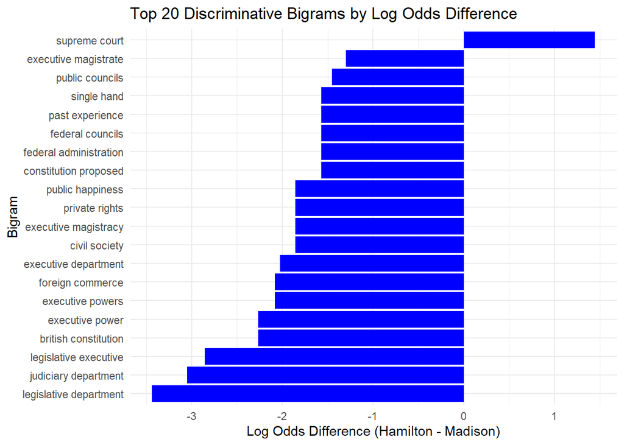

```r
#1.2.3. Tokenizing into bigrams, removing stop words, Removing bigrams occuring once.
data(stop_words)

federalist_clean_nostop <- federalist_clean |>
  mutate(
    text = removeWords(text, stop_words$word))

federalist_bigrams <- federalist_clean_nostop |>
  unnest_tokens(bigram, text, token="ngrams",n=2) |>
  count(bigram, sort = T) |>
  filter(n>1)


#4. Separate bigrams by Hamilton/Madison

bigrams_by_author <- federalist_clean |>
  filter(author %in% c("HAMILTON", "MADISON")) |>
  unnest_tokens(bigram, text, token = "ngrams", n = 2) |>
  separate(bigram, into = c("word1","word2"), sep = " ") |>
  filter(!word1 %in% stop_words$word, !word2 %in% stop_words$word) |>
  unite(bigram, word1, word2, sep = " ") |>
  count(author, bigram, sort = T) |>
  filter (n>1)
#5. Relative frequencies of bigrams for each author

bigrams_rel <- bigrams_by_author |>
  group_by(author) |>
  mutate(total = sum(n),
         frequency = n / total)

#6. Log odds for each bigram

bigrams_log_odds <- bigrams_rel |>
  mutate(log_odds = log(frequency / (1 - frequency)))


#7. Log odds differences for each bigram

bigrams_diff <- bigrams_log_odds |>
  select(author, bigram, log_odds) |>
  pivot_wider(names_from = author, values_from = log_odds) |>
  filter(!is.na(HAMILTON), !is.na(MADISON)) |>  # keep only bigrams present in both
  mutate(log_odds_diff = HAMILTON - MADISON)

#8. Plotting the log odds differences of top discriminative bigrams

top_diff <- bigrams_diff |>
  arrange(desc(abs(log_odds_diff))) |>
  slice(1:20)

ggplot(top_diff, aes(x = reorder(bigram, log_odds_diff), y = log_odds_diff)) +
  geom_col(fill = "blue") +
  coord_flip() +
  labs(x = "Bigram",
       y = "Log Odds Difference (Hamilton - Madison)",
       title = "Top 20 Discriminative Bigrams by Log Odds Difference") +
  theme_minimal()
```